# Predict the house price

**Statement** As a new Kaggler who just created his account a day ago, I am quite excited to hand in my first submission. Without any professional background in CS/Statistics, I have learned data mining, machine learning and R by myself. My lack of experience may make the model not perfect, but I do love to share my opinions. And I hope my dear experienced Kaggle friends can give me some advice/suggestion/criticism of this project. Thanks in advance.

**Updated** Seems that I have to learn to implement XGBoost model if I want a higher score in the competition. The package is amazingly convenient, however I also encountered the problem of parameter tuning. Meanwhile, it seems to be true that my feature engineering is too naive. With different categorical variables, I need to examine them one by one rather than transform them to integer directly. I will try to do this later and see the magic of feature engineering.

### Read Data and Load Packages

```r
# Load Packages
library(MASS)
library(Metrics)
library(corrplot)
library(randomForest)
library(lars)
library(ggplot2)
library(xgboost)
library(Matrix)
library(methods)
```

```r
# Read Data
Training <- read.csv("train.csv")
Test <- read.csv("test.csv")
# Test whether data is successfully loaded
names(Training)
```

```
##  [1] "Id"            "MSSubClass"    "MSZoning"      "LotFrontage"
##  [5] "LotArea"       "Street"        "Alley"         "LotShape"
##  [9] "LandContour"   "Utilities"     "LotConfig"     "LandSlope"
## [13] "Neighborhood"  "Condition1"    "Condition2"    "BldgType"
## [17] "HouseStyle"    "OverallQual"   "OverallCond"   "YearBuilt"
## [21] "YearRemodAdd"  "RoofStyle"     "RoofMatl"      "Exterior1st"
## [25] "Exterior2nd"   "MasVnrType"    "MasVnrArea"    "ExterQual"
## [29] "ExterCond"     "Foundation"    "BsmtQual"      "BsmtCond"
## [33] "BsmtExposure"  "BsmtFinType1"  "BsmtFinSF1"    "BsmtFinType2"
## [37] "BsmtFinSF2"    "BsmtUnfSF"     "TotalBsmtSF"   "Heating"
## [41] "HeatingQC"     "CentralAir"    "Electrical"    "X1stFlrSF"
## [45] "X2ndFlrSF"     "LowQualFinSF"  "GrLivArea"     "BsmtFullBath"
## [49] "BsmtHalfBath"  "FullBath"      "HalfBath"      "BedroomAbvGr"
## [53] "KitchenAbvGr"  "KitchenQual"   "TotRmsAbvGrd"  "Functional"
## [57] "Fireplaces"    "FireplaceQu"   "GarageType"    "GarageYrBlt"
## [61] "GarageFinish"  "GarageCars"    "GarageArea"    "GarageQual"
## [65] "GarageCond"    "PavedDrive"    "WoodDeckSF"    "OpenPorchSF"
## [69] "EnclosedPorch" "X3SsnPorch"    "ScreenPorch"   "PoolArea"
## [73] "PoolQC"        "Fence"         "MiscFeature"   "MiscVal"
## [77] "MoSold"        "YrSold"        "SaleType"      "SaleCondition"
## [81] "SalePrice"
```

After that, the whole procedure has begun. I divide the whole process into four steps:

- Data Cleansing
- Descriptive Analysis
- Model Selection
- Final Prediction

### Data Cleansing

It is important to clean the data with some specific rules, otherwise the precision of result can be jeopardized. After summarizing training set, it is not diffcult to find that some data columns got too many missing values. We first have look on the number of missing values in every variable.

```r
Num_NA<-sapply(Training,function(y)length(which(is.na(y)==T)))
NA_Count<- data.frame(Item=colnames(Training),Count=Num_NA)

NA_Count
```

```
##                        Item Count
## Id                       Id     0
## MSSubClass       MSSubClass     0
## MSZoning           MSZoning     0
## LotFrontage     LotFrontage   259
## LotArea             LotArea     0
## Street               Street     0
## Alley                 Alley  1369
## LotShape           LotShape     0
## LandContour     LandContour     0
## Utilities         Utilities     0
## LotConfig         LotConfig     0
## LandSlope         LandSlope     0
## Neighborhood   Neighborhood     0
## Condition1       Condition1     0
## Condition2       Condition2     0
## BldgType           BldgType     0
## HouseStyle       HouseStyle     0
## OverallQual     OverallQual     0
## OverallCond     OverallCond     0
## YearBuilt         YearBuilt     0
## YearRemodAdd   YearRemodAdd     0
## RoofStyle         RoofStyle     0
## RoofMatl           RoofMatl     0
## Exterior1st     Exterior1st     0
## Exterior2nd     Exterior2nd     0
## MasVnrType       MasVnrType     8
## MasVnrArea       MasVnrArea     8
## ExterQual         ExterQual     0
## ExterCond         ExterCond     0
## Foundation       Foundation     0
## BsmtQual           BsmtQual    37
## BsmtCond           BsmtCond    37
## BsmtExposure   BsmtExposure    38
## BsmtFinType1   BsmtFinType1    37
## BsmtFinSF1       BsmtFinSF1     0
## BsmtFinType2   BsmtFinType2    38
## BsmtFinSF2       BsmtFinSF2     0
## BsmtUnfSF         BsmtUnfSF     0
## TotalBsmtSF     TotalBsmtSF     0
```

[output cut: 27 more lines]

```
## WoodDeckSF       WoodDeckSF     0
## OpenPorchSF     OpenPorchSF     0
## EnclosedPorch EnclosedPorch     0
## X3SsnPorch       X3SsnPorch     0
## ScreenPorch     ScreenPorch     0
## PoolArea           PoolArea     0
## PoolQC               PoolQC  1453
## Fence                 Fence  1179
## MiscFeature     MiscFeature  1406
## MiscVal             MiscVal     0
## MoSold               MoSold     0
## YrSold               YrSold     0
## SaleType           SaleType     0
## SaleCondition SaleCondition     0
## SalePrice         SalePrice     0
```

```r
Training<- Training[,-c(7,73,74,75)]
```

Then, I transferred dummny variables into numeric form. Due to the intimidating size of dummy variables, I decided to transfer them directly by implementing ‘as.integer’ method. This is why I let the string as factor when reading the data file. The numeric variables are sorted out in particular for the convenience of descriptive analysis.

```r
# Numeric Variables
Num<-sapply(Training,is.numeric)
Num<-Training[,Num]

for(i in 1:77){
  if(is.factor(Training[,i])){
    Training[,i]<-as.integer(Training[,i])
  }
}

# Test
Training$Street[1:50]
```

```
##  [1] 2 2 2 2 2 2 2 2 2 2 2 2 2 2 2 2 2 2 2 2 2 2 2 2 2 2 2 2 2 2 2 2 2 2 2
## [36] 2 2 2 2 2 2 2 2 2 2 2 2 2 2 2
```

Finally, for the remaining missing values, I replaced them with zero directly. The data cleansing procedure ends here.

```r
Training[is.na(Training)]<-0
Num[is.na(Num)]<-0
```

### Descriptive Analysis

We first draw a corrplot of numeric variables. Those with strong correlation with sale price are examined.

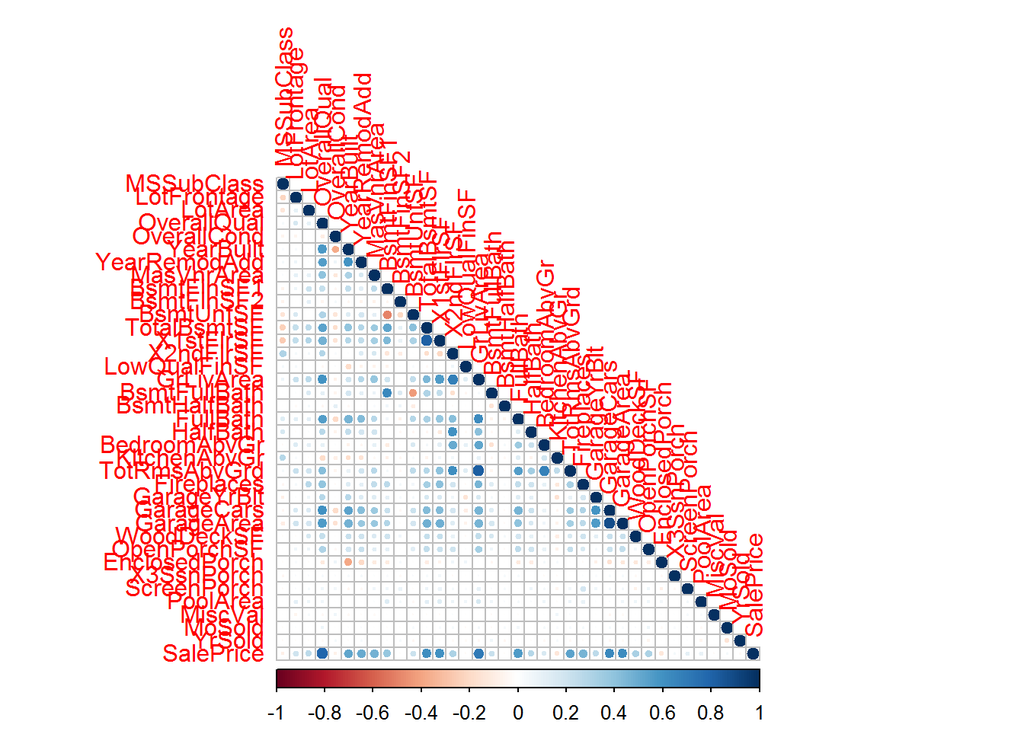

```r
correlations<- cor(Num[,-1],use="everything")
corrplot(correlations, method="circle", type="lower",  sig.level = 0.01, insig = "blank")
```

‘OverallQual’,‘TotalBsmtSF’,‘GarageCars’ and ‘GarageArea’ have relative strong correlation with each other. Therefore, as an example, we plot the correlation among those four variables and SalePrice.

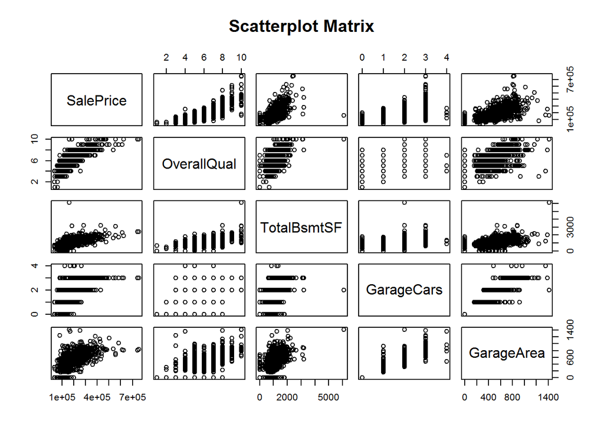

```r
pairs(~SalePrice+OverallQual+TotalBsmtSF+GarageCars+GarageArea,data=Training,
      main="Scatterplot Matrix")
```

The dependent variable (SalePrice) looks having decent linearity when plotting with other variables. However, it is also obvious that some independent variables also have linear relationship with others. The problem of multicollinearity is obvious and should be treated when the quantity of variables in regression formula is huge.

The final descriptive analysis I put here would be the relationship between the variable ‘YearBu’ and Sale Price.

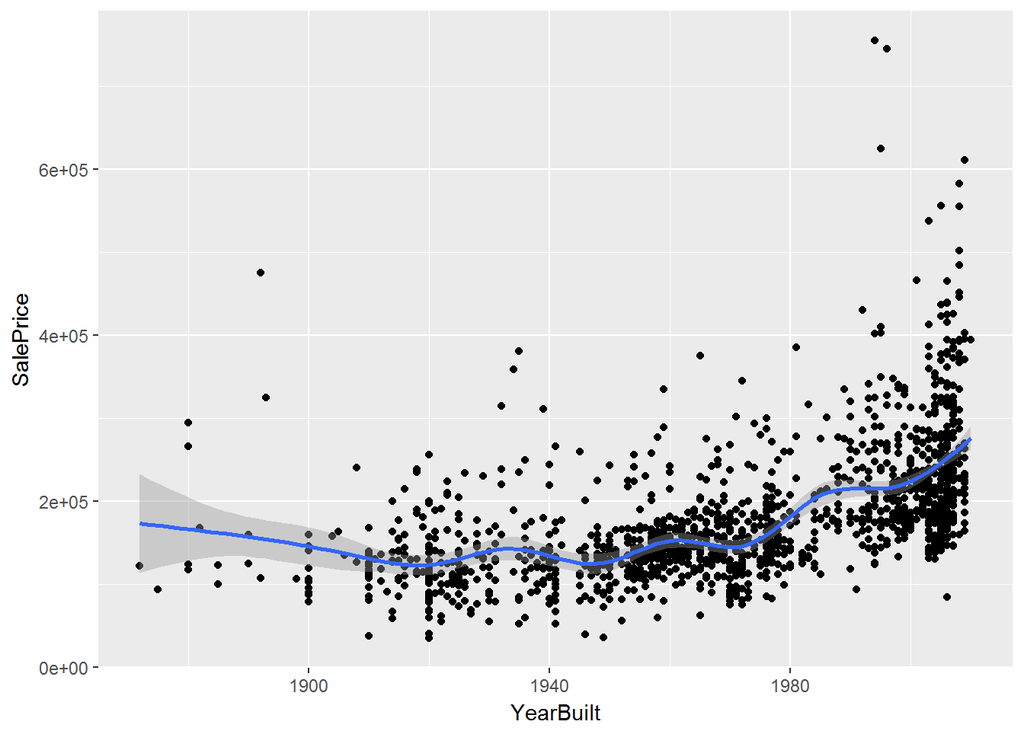

```r
p<- ggplot(Training,aes(x= YearBuilt,y=SalePrice))+geom_point()+geom_smooth()
p
```

It is not diffcult to find that the price of house increases generally with the year built, the trend is obvious.

The workload of data exploration is huge so I decide to end it at here. More details can be digged out by performing descriptive analysis.

### Model Selection

Before implementing models, one should first split the training set of data into 2 parts: a training set within the training set and a test set that can be used for evaluation. Personally I prefer to split it with the ratio of 6:4, *But if someone can tell me what spliting ratio is proved to be scienticfic I will be really grateful*

```r
# Split the data into Training and Test Set # Ratio: 6:4 ###
Training_Inner<- Training[1:floor(length(Training[,1])*0.6),]
Test_Inner<- Training[(length(Training_Inner[,1])+1):1460,]
```

#### Model 1: Linear Regression

The first and simplest but useful model is linear regression model. As the first step, I put all variables into the model.

```r
reg1<- lm(SalePrice~., data = Training_Inner)
summary(reg1)
```

```
##
## Call:
## lm(formula = SalePrice ~ ., data = Training_Inner)
##
## Residuals:
##     Min      1Q  Median      3Q     Max
## -353089  -12679   -1303   12824  192934
##
## Coefficients: (3 not defined because of singularities)
##                 Estimate Std. Error t value Pr(>|t|)
## (Intercept)    1.727e+06  1.577e+06   1.095 0.273758
## Id             5.145e+00  4.020e+00   1.280 0.200927
## MSSubClass    -7.137e+01  5.163e+01  -1.382 0.167288
## MSZoning      -6.364e+02  1.736e+03  -0.367 0.714012
## LotFrontage    6.470e+01  3.604e+01   1.795 0.073004 .
## LotArea        4.153e-01  1.070e-01   3.882 0.000112 ***
## Street         3.691e+04  1.589e+04   2.323 0.020440 *
## LotShape       4.445e+01  8.016e+02   0.055 0.955793
## LandContour    7.364e+02  1.642e+03   0.449 0.653842
## Utilities             NA         NA      NA       NA
## LotConfig     -6.138e+02  6.372e+02  -0.963 0.335765
## LandSlope      2.892e+03  4.470e+03   0.647 0.517902
## Neighborhood   3.793e+02  1.855e+02   2.045 0.041205 *
## Condition1    -1.559e+03  1.232e+03  -1.265 0.206123
## Condition2    -1.396e+04  3.704e+03  -3.768 0.000177 ***
## BldgType      -1.807e+03  1.719e+03  -1.051 0.293528
## HouseStyle    -4.448e+02  7.872e+02  -0.565 0.572191
## OverallQual    1.141e+04  1.419e+03   8.041 3.18e-15 ***
## OverallCond    3.711e+03  1.273e+03   2.916 0.003642 **
## YearBuilt      1.703e+02  9.029e+01   1.886 0.059677 .
## YearRemodAdd   1.613e+02  7.953e+01   2.028 0.042881 *
## RoofStyle     -2.340e+02  1.378e+03  -0.170 0.865179
## RoofMatl       4.512e+03  1.698e+03   2.658 0.008023 **
## Exterior1st   -9.145e+02  5.870e+02  -1.558 0.119652
## Exterior2nd    5.244e+02  5.397e+02   0.972 0.331482
## MasVnrType     2.804e+03  1.801e+03   1.556 0.120022
## MasVnrArea     2.041e+01  6.895e+00   2.960 0.003163 **
## ExterQual     -1.039e+04  2.300e+03  -4.516 7.25e-06 ***
## ExterCond      1.164e+03  1.451e+03   0.802 0.422761
## Foundation     8.281e+02  2.005e+03   0.413 0.679632
```

[output cut: 38 more lines]

```
## EnclosedPorch  2.808e+00  1.845e+01   0.152 0.879115
## X3SsnPorch     8.680e+00  3.110e+01   0.279 0.780229
## ScreenPorch    5.784e+01  1.861e+01   3.108 0.001951 **
## PoolArea      -4.756e+01  3.736e+01  -1.273 0.203345
## MiscVal        3.482e-01  1.799e+00   0.194 0.846521
## MoSold        -6.543e+02  3.799e+02  -1.722 0.085389 .
## YrSold        -1.208e+03  7.821e+02  -1.544 0.122944
## SaleType      -3.676e+02  6.456e+02  -0.569 0.569284
## SaleCondition  4.554e+03  1.005e+03   4.529 6.81e-06 ***
## ---
## Signif. codes:  0 '***' 0.001 '**' 0.01 '*' 0.05 '.' 0.1 ' ' 1
##
## Residual standard error: 28640 on 802 degrees of freedom
## Multiple R-squared:  0.8856, Adjusted R-squared:  0.8752
## F-statistic: 85.02 on 73 and 802 DF,  p-value: < 2.2e-16
```

R Square is not bad, but many variables do not pass the Hypothesis Testing, so the model is not perfect. Potential overfitting will occur if someone insist on using it. Therefore, the variable selection process should be involved in model construction. I prefer to use Step AIC method.

```r
reg1_Modified_2<-lm(formula = SalePrice ~ MSSubClass + LotArea +
                      Condition2 + OverallQual + OverallCond +
                      YearBuilt  + RoofMatl +  ExterQual +
                      BsmtQual + BsmtCond + BsmtFinSF1 + BsmtFinSF2 +
                      BsmtUnfSF + X1stFlrSF + X2ndFlrSF + BedroomAbvGr + KitchenAbvGr +
                      KitchenQual + TotRmsAbvGrd + Functional + Fireplaces + FireplaceQu +
                       GarageYrBlt + GarageCars +  SaleCondition,
                    data = Training_Inner)
summary(reg1_Modified_2)
```

```
##
## Call:
## lm(formula = SalePrice ~ MSSubClass + LotArea + Condition2 +
##     OverallQual + OverallCond + YearBuilt + RoofMatl + ExterQual +
##     BsmtQual + BsmtCond + BsmtFinSF1 + BsmtFinSF2 + BsmtUnfSF +
##     X1stFlrSF + X2ndFlrSF + BedroomAbvGr + KitchenAbvGr + KitchenQual +
##     TotRmsAbvGrd + Functional + Fireplaces + FireplaceQu + GarageYrBlt +
##     GarageCars + SaleCondition, data = Training_Inner)
##
## Residuals:
##     Min      1Q  Median      3Q     Max
## -369683  -14346     -23   12643  197531
##
## Coefficients:
##                 Estimate Std. Error t value Pr(>|t|)
## (Intercept)   -4.556e+05  1.053e+05  -4.327 1.69e-05 ***
## MSSubClass    -1.169e+02  2.812e+01  -4.155 3.58e-05 ***
## LotArea        4.301e-01  9.011e-02   4.774 2.13e-06 ***
## Condition2    -1.249e+04  3.602e+03  -3.468 0.000550 ***
## OverallQual    1.164e+04  1.365e+03   8.530  < 2e-16 ***
## OverallCond    5.480e+03  1.071e+03   5.118 3.81e-07 ***
## YearBuilt      2.480e+02  5.241e+01   4.733 2.59e-06 ***
## RoofMatl       5.771e+03  1.633e+03   3.535 0.000430 ***
## ExterQual     -1.100e+04  2.204e+03  -4.991 7.28e-07 ***
## BsmtQual      -6.840e+03  1.438e+03  -4.755 2.33e-06 ***
## BsmtCond       2.585e+03  1.411e+03   1.832 0.067243 .
## BsmtFinSF1     4.088e+01  5.682e+00   7.196 1.36e-12 ***
## BsmtFinSF2     3.570e+01  7.774e+00   4.592 5.04e-06 ***
## BsmtUnfSF      2.052e+01  5.752e+00   3.568 0.000380 ***
## X1stFlrSF      4.447e+01  6.730e+00   6.607 6.90e-11 ***
## X2ndFlrSF      4.753e+01  4.537e+00  10.476  < 2e-16 ***
## BedroomAbvGr  -7.435e+03  1.896e+03  -3.921 9.52e-05 ***
## KitchenAbvGr  -2.059e+04  5.784e+03  -3.560 0.000392 ***
## KitchenQual   -7.121e+03  1.664e+03  -4.279 2.09e-05 ***
## TotRmsAbvGrd   6.213e+03  1.387e+03   4.479 8.51e-06 ***
## Functional     3.539e+03  1.095e+03   3.232 0.001275 **
## Fireplaces     8.865e+03  2.855e+03   3.106 0.001962 **
## FireplaceQu   -2.081e+03  8.759e+02  -2.375 0.017751 *
## GarageYrBlt   -1.004e+01  2.952e+00  -3.401 0.000704 ***
## GarageCars     1.318e+04  2.333e+03   5.650 2.19e-08 ***
## SaleCondition  4.741e+03  9.834e+02   4.821 1.69e-06 ***
## ---
## Signif. codes:  0 '***' 0.001 '**' 0.01 '*' 0.05 '.' 0.1 ' ' 1
##
## Residual standard error: 29240 on 850 degrees of freedom
## Multiple R-squared:  0.8736, Adjusted R-squared:  0.8699
## F-statistic: 234.9 on 25 and 850 DF,  p-value: < 2.2e-16
```

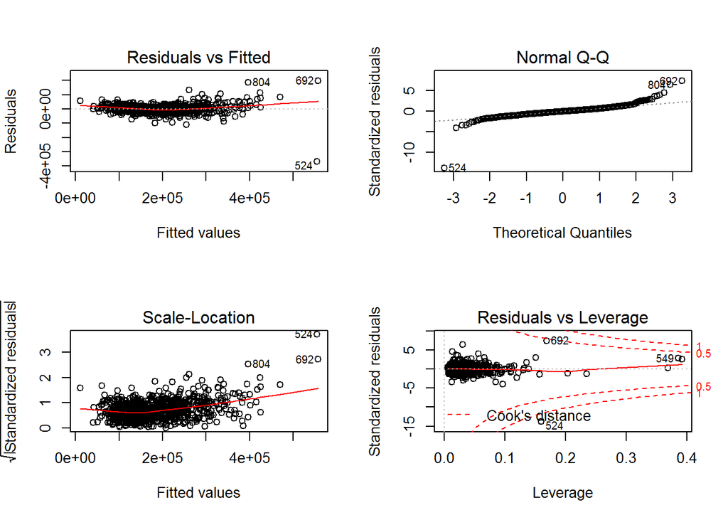

```r
layout(matrix(c(1,2,3,4), 2, 2, byrow = TRUE))
plot(reg1_Modified_2)
```

```r
par(mfrow=c(1,1))
```

We check the performance of linear regression model with RMSE value.

```r
Prediction_1<- predict(reg1_Modified_2, newdata= Test_Inner)
rmse(log(Test_Inner$SalePrice),log(Prediction_1))
```

```
## [1] 0.1808267
```

#### Model 2: LASSO Regression

For the avoidance of multicollinearity, implementing LASSO regression is not a bad idea. Transferring the variables into the form of matrix, we can automate the selection of variables by implementing ‘lars’ method in Lars package.

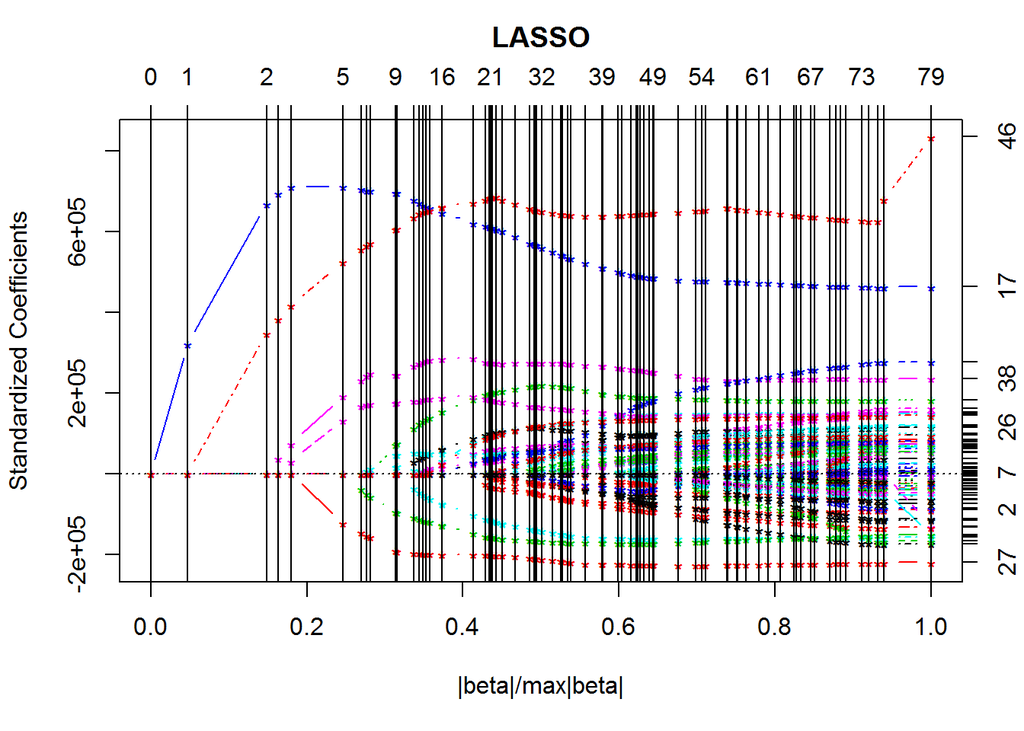

```r
Independent_variable<- as.matrix(Training_Inner[,1:76])
Dependent_Variable<- as.matrix(Training_Inner[,77])
laa<- lars(Independent_variable,Dependent_Variable,type = 'lasso')
plot(laa)
```

The plot is messy as the quantity of variables is intimidating. Despite that, we can still use R to find out the model with least multicollinearity. The selection procedure is based on the value of Marrow’s cp, an important indicator of multicollinearity. The prediction can be done by the script-chosen best step and RMSE can be used to assess the model.

```r
best_step<- laa$df[which.min(laa$Cp)]
Prediction_2<- predict.lars(laa,newx =as.matrix(Test_Inner[,1:76]), s=best_step, type= "fit")
rmse(log(Test_Inner$SalePrice),log(Prediction_2$fit))
```

```
## [1] 0.1623512
```

#### Model 3: Random Forest

The other model I chose to fit in the training set is Random Forest model. The model, prediction and RMSE calculation can be found below:

```r
for_1<- randomForest(SalePrice~.,data= Training_Inner)
Prediction_3 <- predict(for_1, newdata= Test_Inner)
rmse(log(Test_Inner$SalePrice),log(Prediction_3))
```

```
## [1] 0.1490694
```

Obviously, Random Forest may produce the best result within the training set so far.

#### Model 4: XGBoost

This amazing package really impressed me! And I have enthusiam to explore it. The first step of XGBoost is to transform the dataset into Sparse matrix.

```r
train<- as.matrix(Training_Inner, rownames.force=NA)
test<- as.matrix(Test_Inner, rownames.force=NA)
train <- as(train, "sparseMatrix")
test <- as(test, "sparseMatrix")
# Never forget to exclude objective variable in 'data option'
train_Data <- xgb.DMatrix(data = train[,2:76], label = train[,"SalePrice"])
```

Then I tune the parameters of xgboost model by building a 20-iteration for-loop. **Not sure whether this method is reliable but really time-consuming**

```r
# Tuning the parameters #
# Creat Empty List
All_rmse<- c()
Param_group<-c()
for (iter in 1:20) {
  param <- list(objective = "reg:linear",
                eval_metric = "rmse",
                booster = "gbtree",
                max_depth = sample(6:10, 1),
                eta = runif(1, 0.01, 0.3),
                gamma = runif(1, 0.0, 0.2),
                subsample = runif(1, 0.6, 0.9),
                colsample_bytree = runif(1, 0.5, 0.8)

  )
  cv.nround = 500
  cv.nfold = 4
  mdcv <- xgb.cv(data=train_Data, params = param, nthread=6,
                 nfold=cv.nfold, nrounds=cv.nround,verbose = TRUE)
 # Least Mean_Test_RMSE as Indicator #
  min_rmse<- min(mdcv[,test.rmse.mean])
  All_rmse<-append(All_rmse,min_rmse)
  Param_group<-append(Param_group,param)
  # Select Param
  param<-Param_group[(which.min(All_rmse)*8+1):(which.min(All_rmse)*8+8)]
}
```

Then, the parameter can be selected by the random process. Since the process is relatively boring, I just skip it in RMarkdown file and use the optimal parameters I got in my local R script for the prediction and evaluation. ** Can I ask some more efficient and intelligent method of parameter tuning from smart Kagglers? Looking forward to your advice!!**

```r
param<-list(
  objective = "reg:linear",
  eval_metric = "rmse",
  booster = "gbtree",
  max_depth = 8,
  eta = 0.123,
  gamma = 0.0385,
  subsample = 0.734,
  colsample_bytree = 0.512
)
```

The model should be tested before making actual prediction.

```r
Training <-
  xgb.train(params = param,
            data = train_Data,
            nrounds = 600,
            watchlist = list(train = train_Data),
            verbose = TRUE,
            print_every_n = 50,
            nthread = 6)
test_data <- xgb.DMatrix(data = test[,2:76])

prediction <- predict(Training, test_data)
rmse(log(Test_Inner$SalePrice),log(prediction))
```

```
## [1] 0.1404263
```

### Final Prediction

The final prediction can be done by retraining the training set by using selected parameters. Before prediction, the test set should be transformed into the same form of training set.

```r
# Transforming Test set #
Test<- Test[,-c(7,73,74,75)]
for(i in 1:76){
  if(is.factor(Test[,i])){
    Test[,i]<-as.integer(Test[,i])
  }
}
Test[is.na(Test)]<-0
```

Also, we should not forget to transform the test set into the viable form.

```r
re_train<- as.matrix(Training,rownames.force =NA)
re_train<- as(re_train,'sparseMatrix')
retrain_Data<- xgb.DMatrix(data = re_train[,2:76],label=re_train[,"SalePrice"])
bstSparse_retrain<- xgb.train(params=param,
                              data=retrain_Data,
                              nrounds = 600,
                              watchlist = list(train = retrain_Data),
                              verbose = TRUE,
                              print_every_n = 50,
                              nthread = 2
                              )

Test_Matrix<-as.matrix(Test,rownames.force = FALSE)
Test_Matrix<-as(Test_Matrix,"sparseMatrix")
Test_Matrix<-xgb.DMatrix(data = Test_Matrix[,2:76])
```

Then the prediction process begins.

```r
Submit<- predict(Training, newdata=Test_Matrix)
Submit<-data.frame(Id= Test$Id, SalePrice= Submit)
```

*END* Open to any advice/suggestion/criticism. Advice on the choice of other better models is particularily appreciated!!!!!!!!!!!!!!!!!!!!!!!!!